# Visualisierung und Analyse von numerischen Algorithmen

## Skalare Felder

In den Anwendungen treten sehr häufig sogenannte skalare Felder auf. Simpel formuliert sind dies Funktionen von zwei reellen Variablen mit einer reellen Zahl als Funktionswert:

$$z = f(x,y)$$

. Beispiele für solche Funktionen sind folgende Funktionsvorschriften:

1. f(x,y)=x3−3x+y4−2y2,
2. die Rosenbrock-Funktion f(x,y)=(1−x)2+100∗(y−x2)2

Die Rosenbrock-Banane ist ein häufig verwendetes Beispiel für Benchmarks verschiedener Algorithmen und steht sogar als Funktion in SciPy direkt zur Verfügung. In Büchern zum Thema Vektoranalysis und im Skript der Vorlesung Computerorientierte Mathematik finden wir viele weitere Funktionen f(x,y).

### Wir betrachten die angegebene Funktionsvorschriften:

$$f(x,y)=x^3 - 3x + y^4 - 2y^2$$

Wobei die Minimum-Wert bei dieser Funktion ist: $f(x,y) = (1,1)$ das führt unser Funktionswert zu: $f(1,1) = -3$

```python
import numpy as np
import matplotlib.pyplot as plt

%matplotlib inline
from matplotlib import animation, rc
from IPython.display import HTML, display
Writer = animation.writers['pillow']
writer = Writer(fps=15, metadata=dict(artist='Me'), bitrate=1800)

from mpl_toolkits.mplot3d import Axes3D
from matplotlib.colors import LogNorm

from autograd import elementwise_grad, value_and_grad
from scipy.optimize import minimize
from collections import defaultdict
from itertools import zip_longest
from functools import partial

import numpy as np
import matplotlib.pyplot as plt

from matplotlib import cm
from scipy import optimize
```

Wir definiren unser Funktion $f(x,y)=x^3 - 3x + y^4 - 2y^2$ als Methode:

```python
def objfun(x,y):
    return x**3 - 3*x + y**4 - 2*y**2
```

Wir visualisieren die Funktion mithilfe von plots:

```python
def contourplot(objfun, xmin, xmax, ymin, ymax, ncontours=80, fill=True):

    x = np.linspace(xmin, xmax, 200)
    y = np.linspace(ymin, ymax, 200)
    X, Y = np.meshgrid(x,y)
    Z = objfun(X,Y)
    if fill:
        plt.contourf(X,Y,Z,ncontours);
    else:
        plt.contour(X,Y,Z,ncontours);
    plt.scatter(1,1,marker="x",s=50,color="r");  # x als Minimum Zeichen
```

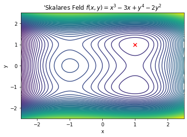

```python
contourplot(objfun, -2.5,2.5, -2.5, 2.5, fill=False)
plt.xlabel("x")
plt.ylabel("y")
plt.title("'Skalares Feld $f(x, y) = x^3 - 3x + y^4 - 2y^2$");
```

# Minimierung von skalaren Feldern

Wie in der Analysis suchen wir auch für diese Funktion $f(x,y)$ Punkte $(x,y)$, für die der Funktionswert ein lokales Minimum darstellt. Wenn wir bei der Metapher einer Landschaft mit Höhenwerte bleiben suchen wir also den tiefsten Punkt in einer Tal.

Genau wie für die Funktionen $f(x)$ gibt es auch für skalare Felder notwendige und hinreichende Kriterien. Aber in den Anwendungen können wir diese Kriterien selten verwenden um auf dem Papier ein lokales Minimum zu bestimmen. Deshalb gibt es im wissenschaftlichen Rechnen das Gebiet der Nichtlinearen Optimierung, die sich mit der numerischen Bestimmung von lokalen Minimam solcher Funktionen auseinandersetzt.

### Dafür gibt es sogenannte Abstiegsverfahren, die immer den gleichen Aufbau haben:

- Wir legen einen Startpunkt $(x0,y0)$ fest, an dem das Verfahren beginnt.
- Wir berechnen eine Suchrichtung, in der wir uns bewegen.
- Wir bestimmen eine Schrittweite, mit der wir in Richtung der Suchrichtung gehen, um eine neue Näherung zu berechnen.
- Wir überprüfen, ob die Abbruchkriterien erfüllt sind. Falls ja stoppt die Iteration, falls nein berechnen wir eine neue Suchrichtung und führen eine weitere Iteration durch.

# Optimierung und Minimierung durch Newton-Verfahren

Wir implementieren die Funktion, die wir minimieren möchten. Dabei schreibt SciPy vor, dass die übergebene Funktion ein Array als Argument hat. Deshalb verwenden wir hier die oben implementierte Funktion f. Wir legen einen Startwert fest, rufen dann optimize.minimize auf und können anschließend die berechneten Ergebnis ausgeben. Als Beispiel verwenden wir hier das Newton-Verfahren.

#### gradient

```python
def gradient(x,y):
    return np.array([3*x**2 - 1, 4*y**2 - 1])
```

#### Wir definieren unser Funktion y:

```python
f  = lambda x, y: x**3 - 3*x + y**4 - 2*y**2

xmin, xmax, xstep = -2.5, 2.5, .1
ymin, ymax, ystep = -2.5, 2.5, .1
n = 1000
x, y = np.meshgrid(np.arange(xmin, xmax + xstep, xstep), np.arange(ymin, ymax + ystep, ystep))

z = f(x, y)
```

##### Wir definieren Minimum-Wert und als Ausgabe f(x,y) = -3

```python
minima = np.array([1,1])
f(*minima)
```

```
-3
```

```python
minima_ = minima.reshape(-1, 1)
minima_
```

```
array([[1],
       [1]])
```

```python
f(*minima_)
```

```
array([-3])
```

## Startwert festlegen und Näherung für ein lokales Minimum berechnen

Wir verwenden minimize(method=’Newton-CG’) und wir initialisieren die Liste mit Startpunkt und wir verfolgen Funktionsvorschrift bis wir bei Punkt (1,1) sind:

```python
x0 = np.array([2,2]) # Startpunkt

func = value_and_grad(lambda args: objfun(*args))

result = minimize(func, x0=x0, method='Newton-CG', # minimize(method=’Newton-CG’)
               jac=True, tol=1.0e-3, callback=print)
print('-----------------------------------------------------------------------------')
if result.success:
    print('Verfahren hat eine Näherung für ein lokales Minimum berechnet.: ', result.x)
    print('Der Funktionswert an diesem Punkt:', result.fun)
    print('Einige Angaben zum Verlauf des Verfahrens:')
    print('Die Funktion f wurde ', result.nfev, '-mal aufgerufen.')
    print('Es wurden ', result.nit, 'Iterationen ausgeführt')
```

```
[1.77530776 1.40082068]
[1.32414521 1.02396168]
[1.03984945 0.99897494]
[1.00077581 1.00028688]
[1.0000003  1.00000012]
-----------------------------------------------------------------------------
Verfahren hat eine Näherung für ein lokales Minimum berechnet.:  [1.0000003  1.00000012]
Der Funktionswert an diesem Punkt: -2.999999999999668
Einige Angaben zum Verlauf des Verfahrens:
Die Funktion f wurde  6 -mal aufgerufen.
Es wurden  5 Iterationen ausgeführt
```

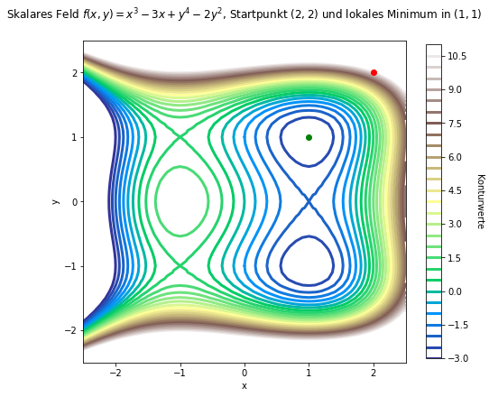

```python
fig = plt.figure(figsize=(8.0, 8.0))
ax = fig.add_subplot(111)
ax.set_aspect('equal')

cplot = plt.contour(x, y, z,
                    levels=levels,
                    cmap=cm.terrain,
                    linewidths=3,
                    origin='lower',
                    extent=(xmin, xmax, ymin, ymax))
plt.xlabel('x')
plt.ylabel('y')
plt.plot(x_0[0], x_0[1], 'ro')
plt.plot(1.0, 1.0, 'go')
plt.title('Skalares Feld $f(x, y) = x^3 - 3x + y^4 - 2y^2$, Startpunkt $(2, 2)$ und lokales Minimum in $(1, 1)$',
          y=1.05,
          fontsize=12)

cbar = plt.colorbar(cplot, shrink=0.8)
cbar.ax.get_yaxis().labelpad = 15
cbar.ax.set_ylabel('Konturwerte', rotation=270)
```

##### Die Ergebnisse sehen plausibel gut aus, wären aber mit etwas Visualisierung überzeugender.

Wir definieren eine neue Rückruffunktion, die die Zwischenwerte an eine Liste anfügt,anstatt sie einfach zu drucken.

```python
def make_minimize_cb(path=[]):

    def minimize_cb(xk):
        path.append(np.copy(xk))

    return minimize_cb
```

```python
path_ = [x0]
```

```python
res = minimize(func, x0=x0, method='Newton-CG',
               jac=True, tol=1.0e-3, callback=make_minimize_cb(path_))
```

Wir wandeln die Liste in ein NumPy-Array und transponieren wir sie:

```python
path = np.array(path_).T
path.shape
```

```
(2, 6)
```

```
(-2.5, 2.5)
```

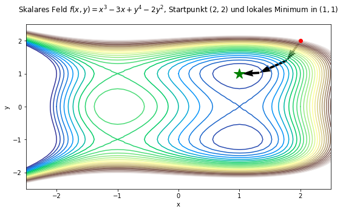

```python
fig, ax = plt.subplots(figsize=(9, 5))

ax.contour(x, y, z, levels=levels, cmap=cm.terrain)
ax.quiver(path[0,:-1], path[1,:-1], path[0,1:]-path[0,:-1], path[1,1:]-path[1,:-1], scale_units='xy', angles='xy', scale=1, color='k')
ax.plot(*minima_, 'g*', markersize=18)

plt.xlabel('x')
plt.ylabel('y')
plt.plot(x_0[0], x_0[1], 'ro')
plt.plot(1.0, 1.0, 'go')
plt.title('Skalares Feld $f(x, y) = x^3 - 3x + y^4 - 2y^2$, Startpunkt $(2, 2)$ und lokales Minimum in $(1, 1)$',
          y=1.05,
          fontsize=12)

ax.set_xlim((xmin, xmax))
ax.set_ylim((ymin, ymax))
```

## Visualisierung durch Static Quiver Plot of Path on 3D Surface Plot

```
(-2.5, 2.5)
```

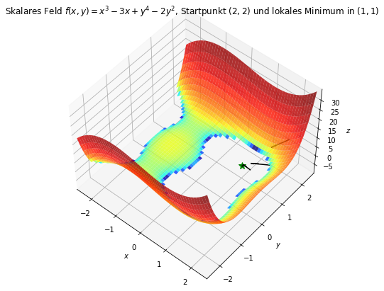

```python
fig = plt.figure(figsize=(10, 7))
ax = plt.axes(projection='3d', elev=50, azim=-50)

ax.plot_surface(x, y, z, norm=LogNorm(), rstride=1, cstride=1, edgecolor='none', alpha=.8, cmap=plt.cm.jet)
ax.quiver(path[0,:-1], path[1,:-1], f(*path[::,:-1]),
          path[0,1:]-path[0,:-1], path[1,1:]-path[1,:-1], f(*(path[::,1:]-path[::,:-1])),
          color='k')
ax.plot(*minima_, f(*minima_), 'g*', markersize=10)

ax.set_xlabel('$x$')
ax.set_ylabel('$y$')
ax.set_zlabel('$z$')
ax.set_title('Skalares Feld $f(x, y) = x^3 - 3x + y^4 - 2y^2$, Startpunkt $(2, 2)$ und lokales Minimum in $(1, 1)$',
          y=1.05,
          fontsize=12)

ax.set_xlim((xmin, xmax))
ax.set_ylim((ymin, ymax))
```

# Animation in Matplotlib

Wir verwenden mächtige Animation Funktion um dies besser zu visualisieren können und die Iterationswert mithilfe Video verfolgen.

- zeichnen 2D Diagramm
- Initialisierung die Linie und Punkte
- mithilfe animation und HTML visualisieren wir Video

Kleine Tutorial : https://jakevdp.github.io/blog/2012/08/18/matplotlib-animation-tutorial/

Wir definieren init() und animate() Funktion um mithilfe von Matplotlib Animation Verlauf von Optimierung und Algorithmen anhand Punkte verfolgen können.

Größe von Graph zuerst definieren wir:

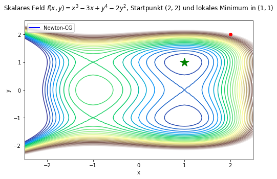

```python
fig, ax = plt.subplots(figsize=(8, 5))

ax.contour(x, y, z, levels=levels, cmap=cm.terrain)
ax.plot(*minima_, 'g*', markersize=18)

# Startpunkt und Newton-CG Alg.
line, = ax.plot([], [], 'b', label='Newton-CG', lw=2)
point, = ax.plot([], [], 'bo')
plt.plot(x_0[0], x_0[1], 'ro') # Startpunkt
plt.title('Skalares Feld $f(x, y) = x^3 - 3x + y^4 - 2y^2$, Startpunkt $(2, 2)$ und lokales Minimum in $(1, 1)$',
          y=1.05,
          fontsize=12)

ax.set_xlabel('x')
ax.set_ylabel('y')

ax.set_xlim((xmin, xmax))
ax.set_ylim((ymin, ymax))

ax.legend(loc='upper left')
```

Startet die Lösung an der Position init, bewegt sich entlang der Newton-Richtung, bis die absolute Differenz zwischen den Funktionswerten unter die Toleranz fällt oder bis die Anzahl der Iterationen den Max überschreitet.

```python
def init():
    line.set_data([], [])
    point.set_data([], [])
    return line, point
```

```python
def animate(i):
    line.set_data(*path[::,:i])
    point.set_data(*path[::,i-1:i])
    return line, point
```

```python
anim = animation.FuncAnimation(fig, animate, init_func=init,
                               frames=path.shape[1], interval=660, # Geschwindigkeit
                               repeat_delay=100, blit=True)
```

```python
HTML(anim.to_jshtml())
```

[figure not shown]